# Project proposal

## Instructions

1. Please answer the following questions as part of your project proposal.
2. Write your answers in the *Markdown* cells of the Jupyter notebook. You don’t need to write any code, but if you want to, you may use the *Code* cells.
3. Use [Quarto](https://quarto.org/docs/output-formats/html-basics.html) to print the *.ipynb* file as HTML. You will need to open the command prompt, navigate to the directory containing the file, and use the command: `quarto render filename.ipynb --to html`. Submit the HTML file.
4. The project proposal is worth 8 points, and is due on **27th January 2023 at 11:59 pm**.
5. You must make one submission as a group, and not individually.
6. Each team member must have at least **one commit** on the team’s github repository. No points will be awarded to the team member(s) with no commits.
7. Share the link of your project’s GitHub repository [here](https://docs.google.com/spreadsheets/d/1khao3unpj_vsx4kOSg_Zzo77YK1UWL2w73Oa0aAirOo/edit#gid=0).

```python
import pandas as pd
import seaborn as sns
```

```python
stroke_data = pd.read_csv('healthcare-dataset-stroke-data.csv')
```

# 1) Team name

Mention your team name.

*(0 points)*

Our team name is **Slay-ta Scientists**.

# 2) Member names

Mention the names of your team members.

*(0 points)*

Our team members are Cara Chang, Amanda Tsuetaki, Rakin Hussian and Allen Zhang.

# 3) Link to the GitHub repository

Share the link of the team’s project repository on GitHub.

Also, put the link of your project’s GitHub repository [here](https://docs.google.com/spreadsheets/d/1khao3unpj_vsx4kOSg_Zzo77YK1UWL2w73Oa0aAirOo/edit#gid=0).

We believe there is no harm in having other teams view your GitHub repository. However, if you don’t want anyone to see your team’s work, you may make the repository *Private* and add your instructor and graduate TA as *Colloborators* in it.

*(0 points)*

https://github.com/cara25/slayta_scientists

# 4) Topic

Mention the topic of your course project.

*(0.25 points)*

Our topic is risk of strokes in patients based on various demographic and clinical indicators.

# 5) Problem statement

Explain the problem statement. The problem statement must include:

1. The problem
2. Is it a regression or classification problem or a combination of both?
3. Is it an inference or prediction problem or a combination of both?
4. How will you assess model accuracy?
- If it is a classification problem, then which measure(s) will you optimize for your model – precision, recall, false negative rate (FNR), accuracy, ROC-AUC etc., and why?
- If it is a regression problem, then which measure(s) will you optimize for your model – RMSE (Root mean squared error), MAE (mean absolute error), maximum absolute error etc., and why?
5. What techniques do you think you may need to use to improve your model? If you have too many variables, some of which are correlated or collinear, you may need to do variable selection *(techniques for variable selection that you will learn later in the course - stepwise regression, lasso, ridge regression)*. If the variables do not have a linear relationship with the response, or if some of the modeling assumptions are not satisfied, you may need to transform the predictors and/or the response (variable transformation) to obtain a better fit.

*(5 points)*

1. The problem statement is to create a model based on various clinical and demographic features (such as BMI, gender, glucose level, and other factors) of a patient to determine if they are likely to have stroke.
2. This will be a classification problem because the analysis of stroke likelihood is a categorical variable.
3. This will also require both prediction and inference: we will use the model to predict stroke likelihood based on the features and also use the model to infer which of the predictors have the strongest association with a higher likelihood of a stroke incidence.
4. To assess model accuracy, we want to minimize the FNR specifically since our stakeholders include people who are at risk of having strokes, and we would rather overpredict people who would get a stroke to be cautious than to accidentally not tell someone that they are at risk of stroke if they do end up getting one (which would be a false positive). However, since most of the people in the dataset did not end up having strokes (the low stroke incidence is featured in the bottom right corner of the pairplot showing stroke distribution), we would want to have our model mirror this by mostly assigning 0’s to people (no stroke), so our model will ideally have high precision and low recall even though we want to specifically minimize FNR.
5. First, look at the correlations of the variables in the data.

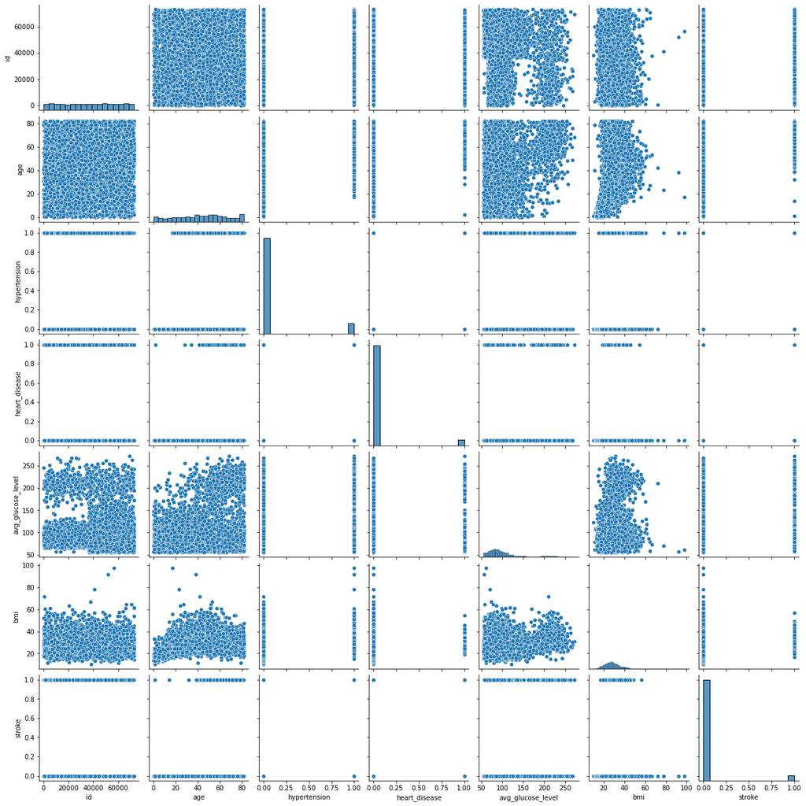

```python
sns.pairplot(stroke_data)
```

```python
stroke_data.corr()
```

|  | id | age | hypertension | heart_disease | avg_glucose_level | bmi | stroke |
| --- | --- | --- | --- | --- | --- | --- | --- |
| id | 1.000000 | 0.003538 | 0.003550 | -0.001296 | 0.001092 | 0.003084 | 0.006388 |
| age | 0.003538 | 1.000000 | 0.276398 | 0.263796 | 0.238171 | 0.333398 | 0.245257 |
| hypertension | 0.003550 | 0.276398 | 1.000000 | 0.108306 | 0.174474 | 0.167811 | 0.127904 |
| heart_disease | -0.001296 | 0.263796 | 0.108306 | 1.000000 | 0.161857 | 0.041357 | 0.134914 |
| avg_glucose_level | 0.001092 | 0.238171 | 0.174474 | 0.161857 | 1.000000 | 0.175502 | 0.131945 |
| bmi | 0.003084 | 0.333398 | 0.167811 | 0.041357 | 0.175502 | 1.000000 | 0.042374 |
| stroke | 0.006388 | 0.245257 | 0.127904 | 0.134914 | 0.131945 | 0.042374 | 1.000000 |

Since there are no quantitative variables that appear to be highly correlated, these all look like potential candidates to include in our model. Since nothing is particularly highly correlated with stroke at first glance, we may need to transform some variables to get a better fit.

```python
stroke_data.head()
```

|  | id | gender | age | hypertension | heart_disease | ever_married | work_type | Residence_type | avg_glucose_level | bmi | smoking_status | stroke |
| --- | --- | --- | --- | --- | --- | --- | --- | --- | --- | --- | --- | --- |
| 0 | 9046 | Male | 67.0 | 0 | 1 | Yes | Private | Urban | 228.69 | 36.6 | formerly smoked | 1 |
| 1 | 51676 | Female | 61.0 | 0 | 0 | Yes | Self-employed | Rural | 202.21 | NaN | never smoked | 1 |
| 2 | 31112 | Male | 80.0 | 0 | 1 | Yes | Private | Rural | 105.92 | 32.5 | never smoked | 1 |
| 3 | 60182 | Female | 49.0 | 0 | 0 | Yes | Private | Urban | 171.23 | 34.4 | smokes | 1 |
| 4 | 1665 | Female | 79.0 | 1 | 0 | Yes | Self-employed | Rural | 174.12 | 24.0 | never smoked | 1 |

Some of these variables are categorical (like smoking_status), and may be transformed into dummy categories for analysis purposes later.

```python
stroke_data.shape
```

```
(5110, 12)
```

Since there are 5110 observations, we should not need to worry aboud sample size limiting the model.

# 6) Data sources

What data sources will you use, and how will the data help answer the questions? Explain.

If the data is open source, share the link of the data.

*(1 point)*

The data source we are using is from Kaggle: https://www.kaggle.com/datasets/fedesoriano/stroke-prediction-dataset

The data will help us answer the questions since it provides various variables about each patient and then tells us whether or not they have a stroke. Then, we can run tests on the data to figure out which variables are the most correlated to our output variable.

# 7) Stakeholders

Who are the stakeholders, and how will your project benefit them? Explain.

*(1 point)*

The stakeholders are anyone concerned about their health, and this tool could be helpful for medical professionals as a preliminary test about whether or not a patient needs to come in for more screening. Obviously, this is nowhere near an end-all solution, but it can be helpful for preliminary purposes.

# 8) Results

What kind of results do you expect?

How much accuracy is required / desired in your model (based on the metric(s) chosen in question 5), such that it is useful to the stakeholders and why?

**Hint:** If it is a classification model, then your model must be at least better than random classification. If it is a regression model, then your model must be at least better than trivial models, such as the one with only the intercept term.

*(0.5 point)*

```python
stroke_data['stroke'].value_counts() / stroke_data['stroke'].count()
```

```
0    0.951272
1    0.048728
Name: stroke, dtype: float64
```

Since we know what the outcomes are already (if a patient had a stroke or not), we want our model to do better than guessing 50/50 if the patient did or did not have a stroke, and because the incidence of stroke in this dataset is around 5%, we would also want our model to do a better job than just assuming every random person had a 5% chance of getting stroke to assess the accuracy of our testing. However, we should still expect that our model will classify most people as not getting a stroke since there is such a low incidence of stroke in the data. We want to be accurate enough to get results close to this 5% incidence, and anything that is around the average stroke incidence in the US should be acceptable so that we can reassure our stakeholders that our results are valid.

# 9) Work-split

How do you plan to split the project work amongst individual team members?

*(0.25 point)*

We plan to be meeting regularly to ensure that everyone will be able to complete their share of the work while also giving everyone a chance to do a distinct part of the project. We will be making sure that everyone understands the processes of github and the way that we will be able to consider communal code. We also have decided to have clear comments on what we are working on in order to signal to our members what our issues may be and to give a clearer train of thought. We have divided our project into sections in order to finish by the given due date. For our presentation, we will each be responsible to explain our code as well as the implications of what this code means. Making a model involves many different considerations and plots and therefore we will have many objectives. If we have difficulties we will also communicate our capabilities in order to make the team the best they can be.